# HW16: PCA Ordination for Stickleback RNA-Seq

# Introduction

**The problem:** Small et al. 2016 conducted an experiment to determine factors that influence gene expression in the gut of stickleback. The main question is the influence of the gut microbiome on gene expression. It is also possible that other factors could influencd transcription, such as the source population of the fish, the genotype (family), or the flask the fish were raised in.

**Plan:** To understand gut transcriptome patterns of variation, I will perform PCA ordination. I will plot each individual fish (which is one RNA-seq library) onto the major axes of variation to collapse multidimensional variation to two dimenstions. I will map experimental treatment, population, and family on the plot to determine whether any of these factors help explain overall transcriptional variation. I will also determine the genes that contribute most to the variation across samples.

# PCA ordination

I used the R function `prcomp` to calculate the similarity matrix and determine the major axes of variatin. The bar graph below shows the percent variation explained by each of the principal components. There cannot be more than 84 PCs because this is the number of samples we have. The first 16 PCs explain more than 1% of the variance (dotted line is across 1%); the rest of the PCs seem negligible. There is not a clear drop-off point, but I decided to show the first 3 PCs in my plots. The first 3 PCs explain 35.2% of the variation, which is a substantial amount.

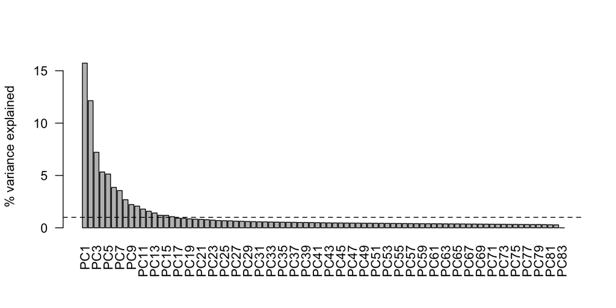

# Experimental treatment status mapped to PCA plot suggests conventional and germ-free treatments do not explain transcriptional variation

Below is the PCA plot, with each dot representing one fish and its place in transcription space on PC1 vs PC2 and PC2 vs PC3. The experimental treatments are mapped in different colors and sex is depicted with M/F above each dot. Neither treatment nor sex seem to contribute to transcriptional variation on these PCs that explain 35.2% of the variation. This plot suggests the microbiome does not contribute greatly to transcriptional variation in these fish.

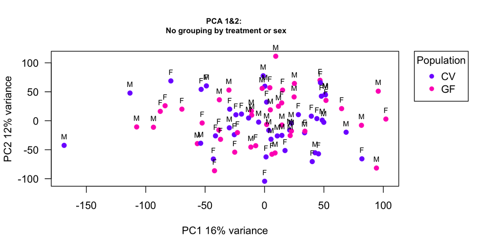

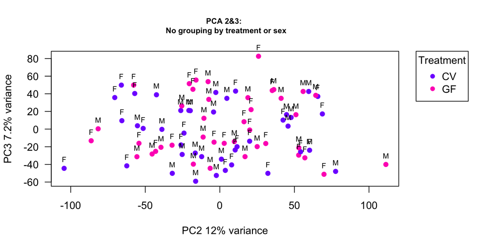

# Population (Ocean/Freshwater) explains transcriptional variation

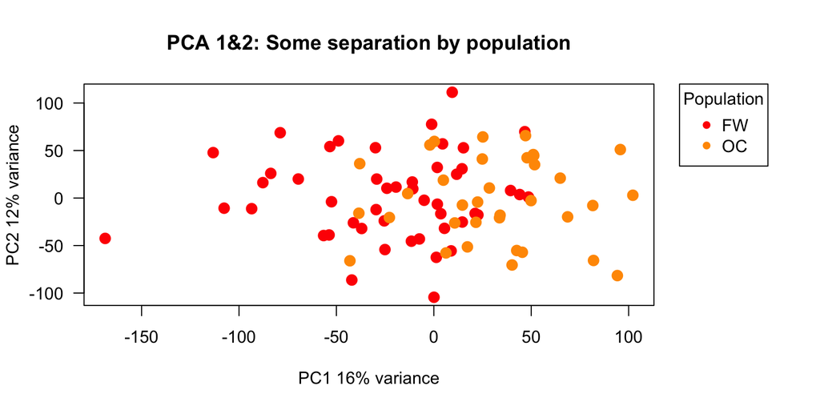

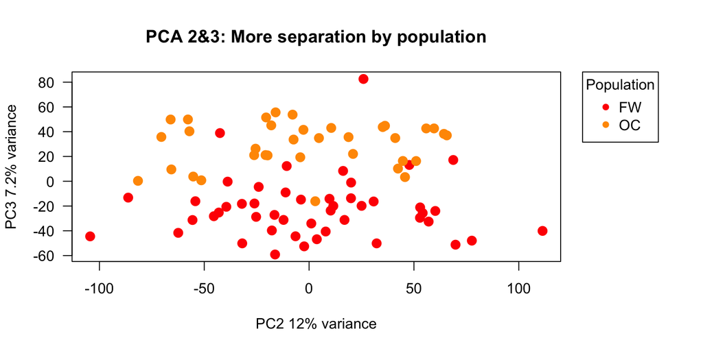

# Family effect (genotype effect) does not explain variation

Since the different populations represent fish from different genotypes, I wanted to check another genotype effect, that of family. I next checked whether the family of fish seems to contribute to variation. I mapped all 5 families onto the PCA plot. We see again the effect of population (OC vs FW), but it is hard to tell an effect of family.

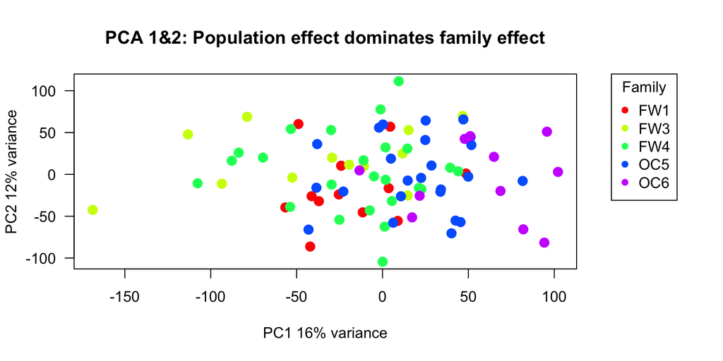

To more closely investigate family, I re-ran the PCA with `prcomp` separately for each population. The two PCA plots are shown below. The families do not seem well-separated, suggesting the genotype effect is prevalent only for more extreme genotype differences (population) and not for smaller genotypic differences due to family.

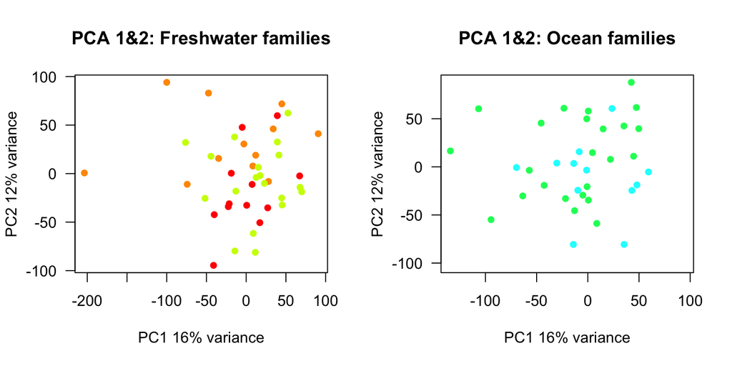

# Genes that contribute to population differences on PC3

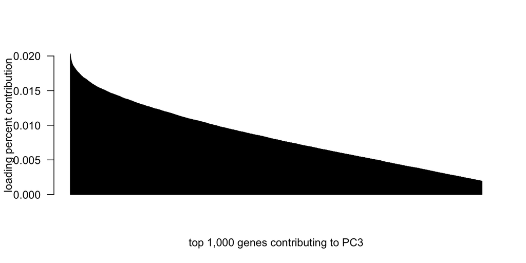

Nevertheless, perhaps the genes with the top loadings can still tell us something about factors that differentiate marine and freshwater stickleback. Future directions of this work will include determining whether these genes are enriched in GO terms. I could also do this GO analysis for the genes from the other loadings. I would also like to know whether the genes that contribute to the population PC have been previously implicated in differentiating marine and freshwater stickleback.

…